# Brain Interaction Networks

Jon Thompson

2022-11-03

# analysis

These analyses focus on overlaps

1. between replicates of the same index protein at different weeks
2. between the networks that have been combined by index across replicates

## plot networks as graphs

### different replicates of the same index protein

#### CACNA1C

[interactive chart not shown]

#### HCN1

[interactive chart not shown]

#### SYNGAP1

[interactive chart not shown]

### combined networks

[interactive chart not shown]

## How do overlaps change under different LFC fold-change cutoffs?

The criteria for including a protein as interactor are generous: “.. defining proteins with log2 FC > 0 and FDR ≤ 0.1 as the significant interactors of the index protein.” ([Hsu et al., 2022, p. 8])”

### how does fold-change FDR cutoff affect the total number of interactors?

select cutoff by

1. adding together all experiments.
2. taking point where distance between observed and expected combined network size (KS-stat) is maximized, where ‘expected’ is on the assumption that interactor FDR p-values are uniformly distributed.

> [!info] Note that we should probably consider re-computing FDR values! However we are using FDR values simply as a measure of association, not for inference)

```
[1] "optimal cutoff:0.017"
```

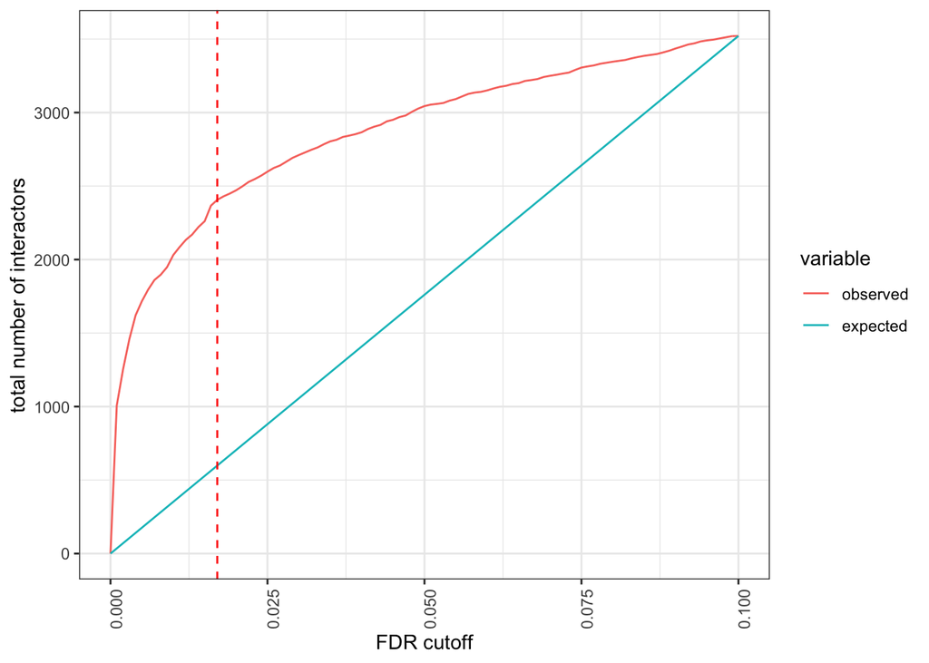

> [!info] we do not actually use this cutoff to filter networks!

It seems that, as we make the LFC FDR value more generous, the rate at which the number of interactors increases begins to tail off around a 0.017 cutoff, suggesting that proteins with higher FDR values may be noise.

### how does FDR cutoff affects the mean degree of an interactor?

In this section, we look at the relationship between the LFC FDR cutoff for interactors and the number of index proteins for which they come up.

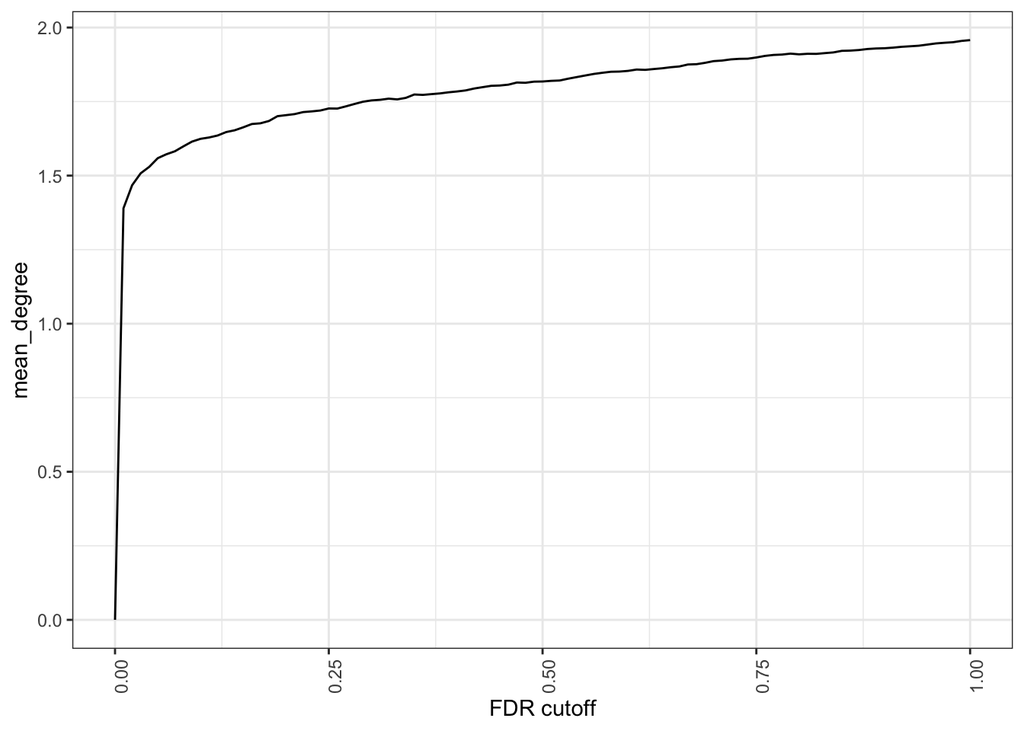

The mean degree of interactors rises quickly initially, then slower as we raise FDR cutoff.

This suggests that the overlap is not noise, since reoccurring interactors tend to have highly significant FC FDR p-values.

Next, we look at the relationship between an interactor’s mean (across indices) minimum (across replicates) FDR, and the number of indexes for which it comes up. I.e.: do recurring interactors tend to have low FDR p-values?

We look at the proteins with non-negative logFC and FDR p-values < 0.1.

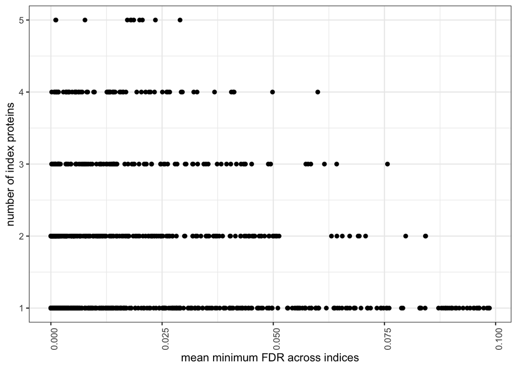

We see that the interactors with an FDR < 0.1 that occur across most indices tend to have a low (highly statistically significant) FDR.

This may suggest that there is a set of interactors that are robustly shared across the index proteins.

What are the hub interactors that are shared between 5 out of 6 index proteins?

| gene | mean_min_FDR |
| --- | --- |
| ATP6V0A1 | 0.001075228 |
| PLXNA4 | 0.001136194 |
| SYT11 | 0.007663267 |
| VDAC2 | 0.017190651 |
| CAMK2G | 0.017947213 |
| SRCIN1 | 0.018063047 |
| CAMK2B | 0.018629245 |
| CNTNAP1 | 0.019951375 |
| CAMK2D | 0.020580073 |
| RAB3A | 0.023503440 |

[output cut: 1 more lines]

None of these are index genes.

What are the interactors that are shared between 4 out of 6 index proteins?

| gene | mean_min_FDR |
| --- | --- |
| KIDINS220 | 0.0001790595 |
| EPHA5 | 0.0007328195 |
| P2RX3 | 0.0008693502 |
| ATP6V0A1 | 0.0010752281 |
| PLXNA4 | 0.0011361944 |
| FLOT1 | 0.0011658394 |
| RBMX | 0.0011975532 |
| TRA2B | 0.0014408803 |
| BANF1 | 0.0016653841 |
| KHDRBS3 | 0.0017203082 |

[output cut: 65 more lines]

## PRS analyses

next steps (done elsewhere): investigate PRS of overlaps

- interactors with degree = 5
- every subset of interactors with degree = 4
- every subset of interactors with degree = 3
- every subset of interactors with degree = 2
- every subset of interactors with degree = 1